# GA4 201 Micro-Application — Explorations (Deeper Analysis)

Module 201: Dive deeper into GA4 data and reports (Intermediate)

Author

Asif Kachroo

Published

February 27, 2026

## 1 1. Training Completion Evidence

**Training Evidence Screenshot 1**

[figure not shown]

## 2 2. Exploration Evidence Screenshots

This analysis uses **Explore → Funnel exploration** in the **GA4 Google Merch Shop** demo property to understand the purchase journey and where users drop off.

### 2.1 Figure 1 — Exploration setup (steps/segments)

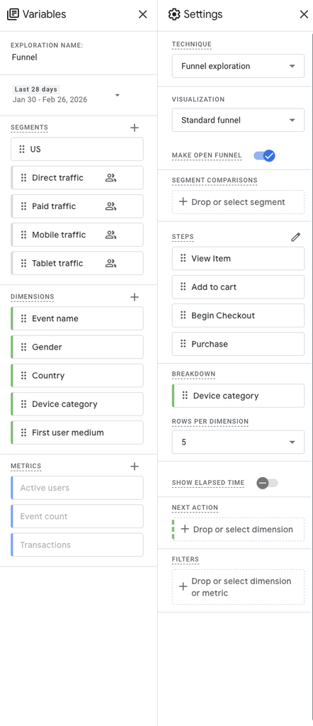

### 2.2 Figure 2 — Exploration results (drop-offs)

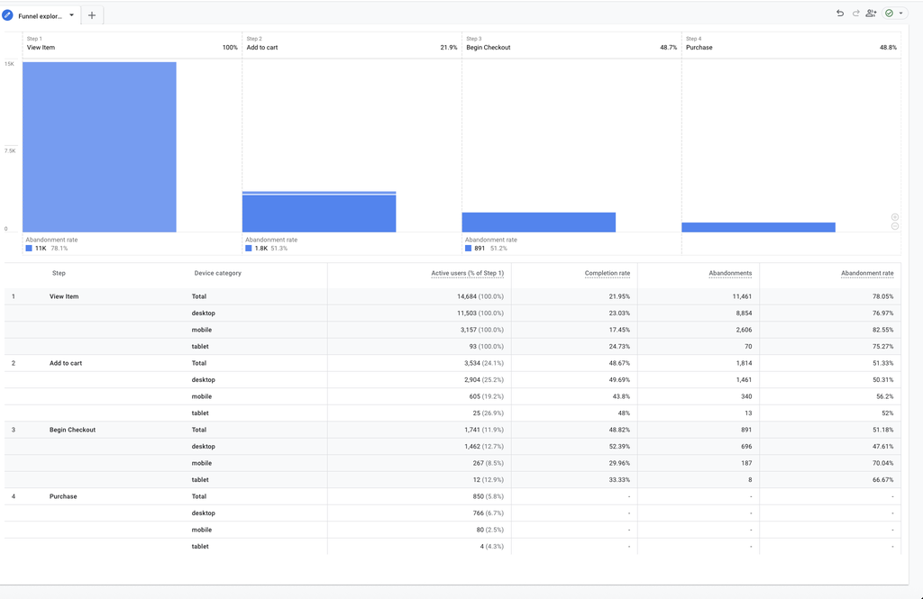

## 3 3. Short Responses

### 3.1 What question were you trying to answer?

I wanted to understand where users drop off in the ecommerce journey and identify the biggest barrier preventing users from completing a purchase.

### 3.2 What did you find?

- Out of **14,684** users who **viewed an item**, only **3,534** added a product to their cart, which is a **78.1% drop-off** from the first step.
- From **Add to cart → Begin checkout**, there was a **51.3% drop-off** (only **1,741** users reached checkout).
- From **Begin checkout → Purchase**, there was a **51.2% drop-off** (only **850** users completed purchase).
- The overall conversion rate from **View Item → Purchase** was **5.8%** (850 out of 14,684).

### 3.3 What’s your next investigation step based on the results? (1–2 sentences)

Next, I would break the funnel down by **device category (mobile vs desktop)** more closely and compare drop-offs to see where mobile users struggle. I would also check **traffic source/medium** to see whether certain channels are bringing lower-intent users.

### 3.4 What’s one action you would recommend for your CEP/client?

- Improve product pages to increase add-to-cart rate (stronger CTA, clearer pricing/shipping info, and better product visuals).
- Reduce checkout friction (fewer steps/fields and improved mobile checkout experience) to lower abandonment between checkout and purchase.